# Taller 1

20582- Anàlisi de Dades

Author

Joan Camps Tomas

Published

November 12, 2024

[Enllaç](https://github.com/JoanCT/Taller_Parcial1.git) d’accés al repositori del treball.

## Introducció

En els dos darrers anys han irromput amb força les eines d’intel·ligència artificial (a partir d’ara, IA) en el món educatiu. Se creu que l’impacte que això pot tenir sobre els estudiants i les seves competències no té precedents, i s’estan prenent mesures al respecte. Alguns consideren que l’ús abusiu d’aquestes eines per part dels estudiants empitjora el seu aprenentatge. Aquesta és precisament la hipòtesi que posarem a prova: l’ús (habitual) d’IA empitjora la qualitat d’aprenentatge dels estudiants universitaris.

Per avaluar la hipòtesi, es recullen les dades que a continuació s’especifiquen (en la majoria de casos, significa respondre una pregunta). Les 4 primeres són quantitatives, les 2 posteriors són nomials, i les 3 darreres, ordinals

- Nota mitjana cursos 2021, 2022
- Nota mitjana cursos 2023, 2024
- Hores setmanals d’estudi convencional (fora IA)
- Hores setmanals d’ús d’eines d’IA
- Quin tipus de grau estudies? (Ciències formals, Enginyeries, Humanitats, Social)
- Fas servir eines IA de pagament? (Si, No) Preguntes a contestar amb Gens-Poc-Suficient-Bastant-Molt
- Quina importància dones a la IA?
- Consider que amb la IA m’esforç manco.
- Consider que tot els resultats que obtenc amb IA els sabria replicar pel teu compte.

Per comprovar la validesa de la hipòtesi, per una banda, si els estudiants amb millors notes utilitzen molta IA, i per l’altra ho comprovarem entre aquells estudiants que han millorat o empitjorat més les qualificacions. També, comprovarem la seva valoració subjectiva.

## Recol·lecció de dades.

El primer pas consisteix en crear una taula amb les dades que es faran servir per dur a terme l’estudi. Una vegada obtingudes les dades, afegim una nova variable que sigui la diferència entre les notes obtingudes abans i després de la IA. Com que les dues variables a restar són normals multivariants, la nova variable també ho serà

```
Rows: 150
Columns: 10
$ notes_pre_IA <dbl> 9.6, 4.8, 10.0, 2.0, 9.0, 10.0, 4.6, 5.5, 4.8, 6.6, 3.0, …
$ notes_IA     <dbl> 8.6, 6.5, 7.5, 1.0, 2.0, 6.1, 6.8, 3.1, 2.8, 10.0, 2.2, 4…
$ dif_notes    <dbl> -1.0, 1.7, -2.5, -1.0, -7.0, -3.9, 2.2, -2.4, -2.0, 3.4, …
$ hores_est    <dbl> 11.6, 12.8, 11.0, 10.5, 10.9, 13.1, 9.8, 10.1, 14.0, 9.5,…
$ hores_IA     <dbl> 6.4, 4.1, 3.8, 3.2, 2.6, 4.1, 6.7, 2.5, 2.7, 7.1, 5.9, 7.…
$ estudis      <chr> "Socials", "Tecnics", "Ciencies", "Tecnics", "Socials", "…
$ pagament     <chr> "No", "No", "No", "No", "No", "No", "No", "No", "No", "Si…
$ importancia  <ord> Gens, Suficient, Poc, Suficient, Poc, Gens, Bastant, Bast…
$ esforç       <ord> Suficient, Suficient, Bastant, Molt, Bastant, Poc, Sufici…
$ replicar     <ord> Suficient, Poc, Gens, Bastant, Suficient, Poc, Gens, Poc,…
```

## Anàlisi descriptiu

Cal fer un primer comentari sobre la naturalesa de les dades. Per construcció ja sabem que cada varaible seguirà una distribució normal. Així idò, farem aquesta assumpció d’ara en endavant.

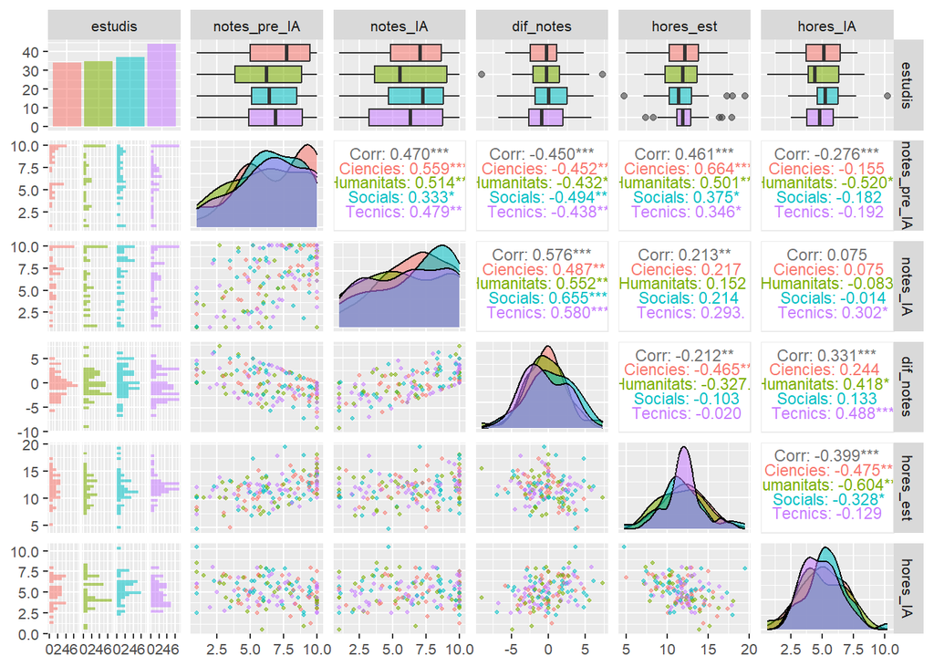

Descrivim a trets generals el conjunt de dades, centrant-nos en aquells aspectes que ens interessen per provar o no la hipòtesi plantejada. S’han agrupat segons la branca de coneixement del grau universitari.

Centrant-nos en els objectius de l’estudi, comprovem si dues de les correlacions són significatives.

```
    Pearson's product-moment correlation

data:  IA_estudiants$hores_IA and IA_estudiants$dif_notes
t = 4.2621, df = 148, p-value = 3.589e-05
alternative hypothesis: true correlation is not equal to 0
95 percent confidence interval:
 0.1799126 0.4661989
sample estimates:
      cor
0.3306408
```

```
    Pearson's product-moment correlation

data:  IA_estudiants$hores_IA and IA_estudiants$hores_est
t = -5.2865, df = 148, p-value = 4.391e-07
alternative hypothesis: true correlation is not equal to 0
95 percent confidence interval:
 -0.5252558 -0.2545392
sample estimates:
      cor
-0.398543
```

Així idò, unes primeres observacions a destacar són el fet que hi ha una correlació positiva entre les hores d’ús d’IA i la la millora en les qualificacions, juntament amb una correlació negativa entre les hores d’estudi convencional i d’ús de IA. De fet, com que els p-valors dels contrasts anteriors són ínfims, podem dir que es poden extendre a la població.

Quant a les mitjanes, sembla ser que la mitjana de diferència entre les notes dels distints tipus de carrera és la mateixa, mentre que hi ha una diferència entre les mitjanes d’ús d’IA per tipus de grau. Comprovem-ho amb un ANOVA d’una via.

```
             Df Sum Sq Mean Sq F value Pr(>F)
estudis       3   14.6   4.876   0.585  0.626
Residuals   146 1216.9   8.335
```

```
             Df Sum Sq Mean Sq F value Pr(>F)
estudis       3    5.9   1.954   0.744  0.528
Residuals   146  383.6   2.628
```

Ara bé, els p-valors en els dos casos són molt elevats, i no podem dir que hi hagi diferència significativa entre les mitjanes de dites variables.

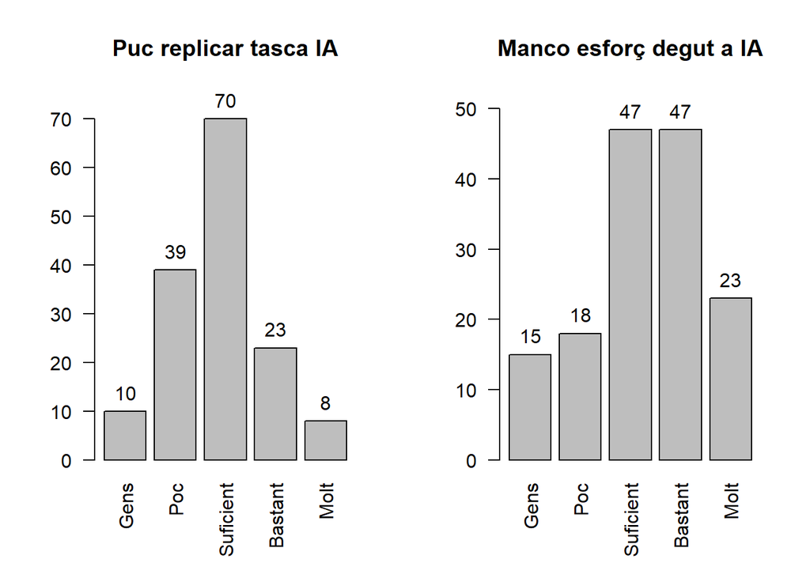

```r
par(mfrow = c(1, 2))

df_3 <- IA_estudiants %>%
    group_by(replicar) %>%
    summarise(count = n())
df_2 <- IA_estudiants %>%
    group_by(esforç) %>%
    summarise(count = n())

bp = barplot(df_3$count, beside = TRUE, names.arg = df_3$replicar, las = 2,
        main = 'Puc replicar tasca IA', ylim = c(0,max(df_3$count)+5))
text(bp, df_3$count, df_3$count, pos = 3, xpd = NA)

bp = barplot(df_2$count, beside = TRUE, names.arg = df_2$esforç, las = 2,
        main = 'Manco esforç degut a IA', ylim = c(0,max(df_2$count)+5))
text(bp, df_2$count, df_2$count, pos = 3, xpd = NA)
```

Observant les gràfiques anteriors, veim que d’entre els estudiants enquestats, n’hi ha més que asseguren no saber replicar els resultats obtinguts amb ajuda de la IA que els que sí saben fer-ho; i la majoria assumeix que gràcies a la IA s’esforça manco en els estudis.

Calculem ara la variància generalitzada i la variància total de les dades.

```
[1] "Variància generalitzada"
```

```
[1] 1.323302e-12
```

```
[1] "Variació total"
```

```
[1] 33.06515
```

## Modelització multinomial

Considerem la vairable aleatòria “replicar”, que dona resposta a l’afirmació “Consider que tot els resultats que obtenc amb IA els sabria replicar pel teu compte”. La modelitzarem com una distribució multinomial. Per això, haurem d’estimar els seus paràmetres:
$$X_{replicar} \sim \text{Multinomial}(n=150, \theta = (\theta_{gens}, \theta_{poc}, \theta_{suficient}, \theta_{bastant}, \theta_{molt}))$$

Evidentment, farem servir l’estimador de màxima versemblança per a cada probabilitat, el qual coincideix amb la freqüència obtinguda en la mostra.

A partir de dit model, vegem la probabilitat d’obtenir una seqüència de respostes molt concreta. De 20 estudiants, que 5 afirmin que saben replicar “suficient”, 5 “bastant” i 10 “molt” allò que obtenen de la IA.

```
[1] 1.626309e-11
```

Suposant un escenari quotidià, possiblement els estudiants no afirmin que saben replicar perfectament tot allò que consulten o que no en saben gens, sinó que tendeixin a valors més neutres. Vegem la probabilitat que 3 afirmin que no saben replicar “gens”, 12 “poc”, 4 “suficient” i 1 “bastant” allò que obtenen de la IA.

```
[1] 7.252626e-06
```

Més interessant pel nostre cas pot ser modelitzar una binomial on es combinin per una banda les respostes de “gens” i “poc” i per altra la resta. Així, volem veure la probabilitat que de 20 estudiants, la meitat assumeixin que no saben replicar allò que produeix la IA.

```
[1] 0.04897201
```

## Regressió multinomial

Provem de modelitzar la variable $X_{\text{notesIA}}$ a partir de les altres tres variables quantitatives. Això és:
$$Y=X_{\text{notesIA}} = \beta_0 + \beta_1 X_{\text{notesPreIA}} + \beta_2 X_{\text{horesEst}} + \beta_3 X_{\text{horesIA}} + \epsilon$$

```
Call:
lm(formula = notes_IA ~ notes_pre_IA + hores_est + hores_IA,
    data = IA_estudiants)

Residuals:
    Min      1Q  Median      3Q     Max
-7.2165 -1.8031 -0.0235  1.7481  5.4950

Coefficients:
             Estimate Std. Error t value Pr(>|t|)
(Intercept)  -0.53504    1.48818  -0.360    0.720
notes_pre_IA  0.54710    0.08761   6.245 4.38e-09 ***
hores_est     0.08925    0.09476   0.942    0.348
hores_IA      0.43911    0.13952   3.147    0.002 **
---
Signif. codes:  0 '***' 0.001 '**' 0.01 '*' 0.05 '.' 0.1 ' ' 1

Residual standard error: 2.509 on 146 degrees of freedom
Multiple R-squared:  0.2703,    Adjusted R-squared:  0.2553
F-statistic: 18.03 on 3 and 146 DF,  p-value: 5.242e-10
```

Veim que una dels coeficients té un p-valor associat gran, de manera que repetim la regressió fora tenir en compte la variable $X_{\text{horesEst}}$. Si aquest model fos precís, podríem extreure una conclusió ben interessant: la nota actual dels estudiants s’explica amb la nota que solien treure i l’ús que fan de les eines de la IA, mentre que les hores d’estudi convencional dedicades no són rellevants.
$$Y=X_{\text{notesIA}} = \beta_0 + \beta_1 X_{\text{notesPreIA}} + \beta_2 X_{\text{horesIA}} + \epsilon$$

```
Call:
lm(formula = notes_IA ~ notes_pre_IA + hores_IA, data = IA_estudiants)

Residuals:
    Min      1Q  Median      3Q     Max
-7.0290 -1.7970 -0.0634  1.9050  5.5293

Coefficients:
             Estimate Std. Error t value Pr(>|t|)
(Intercept)   0.52110    0.97808   0.533  0.59499
notes_pre_IA  0.57996    0.08033   7.220 2.59e-11 ***
hores_IA      0.39729    0.13222   3.005  0.00313 **
---
Signif. codes:  0 '***' 0.001 '**' 0.01 '*' 0.05 '.' 0.1 ' ' 1

Residual standard error: 2.508 on 147 degrees of freedom
Multiple R-squared:  0.2659,    Adjusted R-squared:  0.2559
F-statistic: 26.62 on 2 and 147 DF,  p-value: 1.363e-10
```

Ara sí, tots els dos coeficients surten significatius. Tot i així, veim que el valor $R^2$ ajustat surt de 0.2559, que no és massa gran. No diríem que és una bona aproximació.

Calculem la funció d’score d’aquest darrer model. Tenim el model com
$$Y = \textbf{X}\beta + \epsilon$$
on $\textbf{X}= (1,\textbf{X}_{\text{notesPreIA}}, \textbf{X}_{\text{horesIA}})$, $\beta = (\beta_0, \beta_1, \beta_2)'$, $\epsilon \sim N(0, \sigma^2I)$

En tal cas, la funció de densitat conjunta és
$$f(Y \mid \beta, \sigma^2) = \frac{1}{(2\pi\sigma^2)^{n/2}} \exp\left(-\frac{1}{2\sigma^2}(Y - X\beta)^T(Y - X\beta)\right)$$
Llavors, prenent logaritmes obtenim:

$$\ell(\beta, \sigma^2 \mid Y) = -\frac{n}{2} \log(2\pi\sigma^2) - \frac{1}{2\sigma^2}(Y - X\beta)^T(Y - X\beta)$$

En aquest punt podem obtenir la funció d’score derivant respecte del paràmetre $\beta$. Recordem que les derivades involucrades són matricials.

$$\text{Score}(\beta) = \frac{\partial \ell}{\partial \beta} = \frac{1}{\sigma^2} X^T (Y - X\beta)$$
La funció d’score es vincula amb la màxima versemblança del paràmetre involucrat. Quan l’score s’anul·la, s’ha trobat un valor del paràmetre $\beta$, en aquest cas, dels coeficients que modelitzen la recta, vinculat a un màxim en la funció de versemblança. Així, aquest valor és el que maximitxa la probabilitat d’obtenir les respostes registrades de $X_\text{notesIA}$ a partir d’una combinació lineal de $X_\text{notesPreIA}$ i $X_\text{horesIA}$. Dit altrament, el valor $\hat\beta$ tal que $\text{Score}(\hat\beta)=0$ dona la millor manera d’explicar la mostra de notes dels estudiants a partir de les notes anteriors a l’adveniment de la IA i del seu ús. Contràriament, si el valor de $\beta$ no anul·la l’score, vol dir que podem trobar un valor millor per maximitxar la precisió del model.

## Contrast medianes multivariant

En aquesta secció realitzarem un contrast multivariant de dues mitjanes, entre les subpoblacions d’estudiants que fan servir eines de pagament i els que no. Primer feim el test amb la funció predefinida de R:

```
Test stat:  1.2891
Numerator df:  3
Denominator df:  146
P-value:  0.7362
```

Obtenim un p-valor elevat, i per tant assumim que les mitjanes són igual. Així, no podem dir que hi hagi diferència entre les mitjanes de notes obtingudes, hores d’estudi convencional i hores d’ús de IA dels estudiants que fan servir eines d’IA gratuïtes i no.

Vegem ara el desenvolupament teòric. Suposarem que les matrius de covariàncies són desconegudes. En tal cas, l’estadístic de contrast ve donat per:

$$\frac{n_1 + n_2 - 1 - p}{(n_1 + n_2 - 2)p} \frac{n_1 n_2}{n_1 + n_2} \left(\bar{x} - \bar{y}\right)' \hat{\mathbf{S}}^{-1} \left(\bar{x} - \bar{y}\right) \sim F^p_{n_1 + n_2 - 1 - p}$$

on
$$\hat{\mathbf{S}} = \frac{n_1 \mathbf{S}_1 + n_2 \mathbf{S}_2}{n_1 + n_2 - 2}$$
i $S_1, S_2$ són les matrius de covariància poblacional per cada població.

```
[1] "L'estadístic és: "
```

```
[1] 0.423887
```

Obtenguem el p-valor de l’estadístic a partir de la distribució coneguda:

```
[1] 0.7361556
```

Com esperàvem, arribam al mateix valor que abans, i per tant no tenim indicis suficients per rebutjar la hipòtesi nul·la. Per tant, assumim que ambdós grups d’estudiants presenten el mateix vector de mitjanes

## Bibliografia

1. [Análisis de datos - 3 Inferencia multivariante en poblaciones normales](https://aprender-uib.github.io/AD/t3_inferencia.html#contraste-de-hip%C3%B3tesis-multivariantes).
2. Cuadras, C. M. (1981) Métodos de Análisis Multivariante. Capítulo 2: Normalidad Multivariante.
3. Apunts de l’assignatura sobre regressió lineal i contrasts d’hipòtesis.